# KRM - Benchmark

Sven Gastauer

2023-02-16

Testing the rKRM implementation of the KRM - Kirchhoff Ray Mode - model, based on equations described in detail in ‘Acoustic models of fish: The Atlantic cod (Gadus morhua)’ by Clay and Horne, 1994.

The KRM and the underlying scattering theory holds validity for high frequencies (>>> resonance freqeuncy) and for incident angles between 65 and 115 degrees.

Shapes are approximated shapes through a series of cylinders. x coordinates are the along body coordinates (major axis of an ellipsoid) z coordinates are the upper and lower coordinates at position x (the upper and lower values of the minor axis). w defines the width frpm a top view along the body axis.

The model is split in two parts:  
1) The Swimbladder (or gas bubble) part  
2) The Fish body (or fluid like) part

## Weakly scattering fluid Sphere

To approximate scattering by a fluid sphere through the KRM mo9del, we set the swimbladder part to 0 and only consider the Fish body part.  
We first define the sphere parameters:

```r
library(KRMr)
#Define the the sphere parameters
freqs = 10:400 * 1000 #Hz frequencies to be considered in Hz
a = 0.01 #m radius of the sphere
cw = 1477.4 #m/s sound speed surrounding water
cfb =  1480.3 #m/s soundspeed inside the sphere
rhow = 1026.8 #kg/m3 density surrounding water
rhofb = 1028.9 #kg/m3 density fluid inside sphere
```

Now we can construct shape information that is understoof by the KRM model:

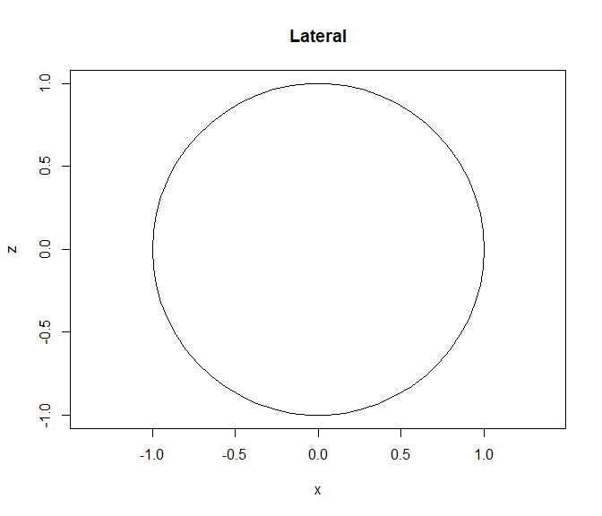

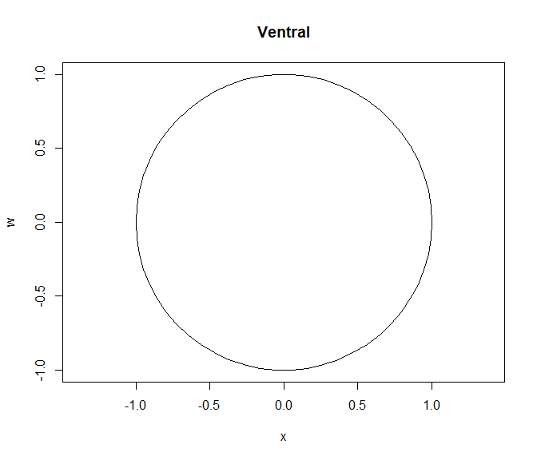

```r
#generate sphere coordinates
ang = seq(-90,90,length.out=30) #angles to consider
xfb = sin(ang * pi / 180) #x coordinates of a sphere
wfb = (2*cos(ang * pi / 180)) #diameter of the sphere
zfbU = cos(ang * pi / 180) #upper z coordinates
zfbL = -cos(ang * pi / 180) #lower z coordiates

shplot(x_fb = xfb,w_fb = wfb,z_fbU = zfbU, z_fbL=zfbL)
```

Now we can run the KRM simulation:

```r
kfs = krm.sim(frequency =10:400 * 1000,
              c.w = cw,
              rho.w = rhow,
              theta=90,
              c.fb = cfb,
              rho.fb = rhofb,
              L=0.02,
              x_fb =xfb,
              x_sb = 0,
              w_fb = wfb,
              w_sb = 0,
              z_fbU = zfbU,
              z_fbL = zfbL,
              z_sbU = 0,
              z_sbL = 0)
```

We will use the analytical solution of the scattering by a fluid sphere as descirbed in Jech et al. 2015, modified from Anderson (1950).

Jech, J. M., Horne, J. K., Chu, D., Demer, D. A., Francis, D. T., Gorska, N., … & Reeder, D. B. (2015).”Comparisons among ten models of acoustic backscattering used in aquatic ecosystem research.” The Journal of the Acoustical Society of America, 138(6), 3742-3764.  
Anderson, V. C. (1950). “Sound scattering from a fluid sphere.” The Journal of the Acoustical Society of America, 22(4), 426-431.

```r
kfs$bench=sapply(freqs,
                 function(f){
                   fsphere(f,a,cw,cfb/cw,
                             rhofb/rhow)})
```

Plotting the results:

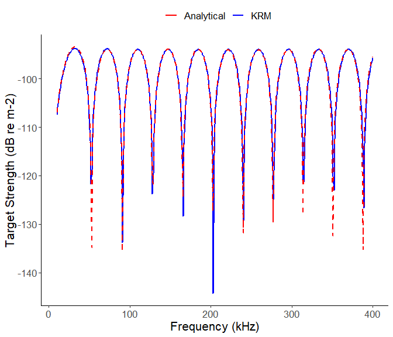

```r
colors <- c("Analytical" = "red", "KRM" = "blue")

ggplot2::ggplot()+
  ggplot2::geom_line(data=kfs, ggplot2::aes(x=frequency/1000,y=TS, group=L,col='KRM'),lwd=1)+
  ggplot2::geom_line(data=kfs, ggplot2::aes(x=frequency/1000, group=L, y=bench,col='Analytical'), lty=2,lwd=1)+
  ggplot2::scale_color_manual(values = colors, name='')+
  ggplot2::xlab('Frequency (kHz)')+
  ggplot2::ylab('Target Strength (dB re m-2)')+
  ggplot2::theme_classic()+
  ggplot2::theme(text=ggplot2::element_text(size=16),
        legend.position='top')
```

## Gas filled fluid sphere

```r
#Define the the sphere parameters
freqs = seq(12,400,1) * 1000 #Hz frequencies to be considered in Hz
a = 0.01 #m radius of the sphere
cw = 1477.4 #m/s sound speed surrounding water
cfb =  345.0 #m/s soundspeed inside the sphere
rhow = 1026.8 #kg/m3 density surrounding water
rhofb = 1.24 #kg/m3 density fluid inside sphere
```

Now we can run the KRM simulation:

```r
kfs = krm.sim(frequency =freqs,
              c.w = cw,
              rho.w = rhow,
              theta=90,
              c.sb = cfb,
              rho.sb = rhofb,
              L=0.02,
              x_sb =xfb,
              w_sb = wfb,
              z_sbU = zfbU,
              z_sbL = zfbL)
```

We will use the analytical solution of the scattering by a fluid sphere as descirbed in Jech et al. 2015, modified from Anderson (1950).

Jech, J. M., Horne, J. K., Chu, D., Demer, D. A., Francis, D. T., Gorska, N., … & Reeder, D. B. (2015).”Comparisons among ten models of acoustic backscattering used in aquatic ecosystem research.” The Journal of the Acoustical Society of America, 138(6), 3742-3764.  
Anderson, V. C. (1950). “Sound scattering from a fluid sphere.” The Journal of the Acoustical Society of America, 22(4), 426-431.

```r
kfs$bench=sapply(freqs,
                 function(f){
                   fsphere(f,a,cw,cfb/cw,
                             rhofb/rhow)})
```

Plotting the results:

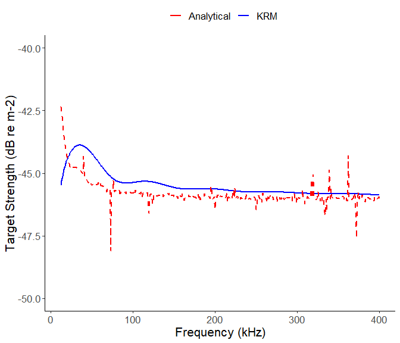

```r
colors <- c("Analytical" = "red", "KRM" = "blue")

ggplot2::ggplot()+
  ggplot2::geom_line(data=kfs, ggplot2::aes(x=frequency/1000,y=TS, group=L,col='KRM'),lwd=1)+
  ggplot2::geom_line(data=kfs, ggplot2::aes(x=frequency/1000, group=L, y=bench,col='Analytical'), lty=2,lwd=1)+
  ggplot2::scale_color_manual(values = colors, name='')+
  scale_y_continuous(limits=c(-50,-40))+
  ggplot2::xlab('Frequency (kHz)')+
  ggplot2::ylab('Target Strength (dB re m-2)')+
  ggplot2::theme_classic()+
  ggplot2::theme(text=ggplot2::element_text(size=16),
        legend.position='top')
```